# Kaia’s Report

Kaia’s Report karmas@uw.edu 10/8/22 Visualization Link

**Title**: “The Best and Worst Places to Grow Up: How Your Area Compares”

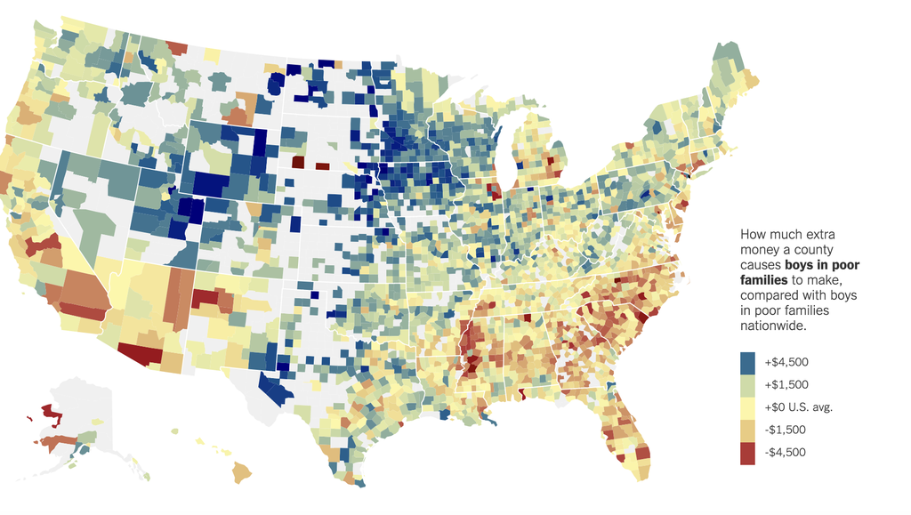

Something I did to find my data visualiztion was to go on the New York Times website and look up different articles that included data visualizations. I chose this data visualization because it was really different since there were a lot of different other visualizations related to politics which didn’t interest me. I was really curious to see where the best and worst places in the US to live. It was really facinating to see majority of the counties around the US in all 50 state. I could choose the different percentiles and to see if I wanted to see the information for all kids or in perticular boys or girls. Visualization Link

There are a few values of missing of some areas but the data visualization shows a map of the US and the different counties that are color coordinated to the the scale on the side. It shows the different amounts girls or boys could earn by a certain age. I am able to switch between different percentiles and choose whether I want to have it all kids or just boys and girls. I realized that for every percentile when I compared between boys and girls, girls would earn more then boys in each percentile. The 99th century had a lot of countries where both boys and girls could make more than $4500 in some counties.

- **Who**:Gregor Aisch, Eric Buth, Matthew Bloch, Amanda Cox and Kebin Quealy
- **Date**: *May 4, 2015*
- **Stakeholders**: The stake holders are for anyone who is looking to have children and where to live.
- **Interests**: The interests are for people looking to buy a house in a good county who have children.])
- **Key fact**: Somethng that can be learned is that Manhattan is a bad place to raise children. It ranked really low in every catagory of the visualization.

## Data Feminism: *What I Learned*

> Data Feminism is the way of thinking about data, it’s analysis, and display that is informed by traditional feminist activism. (page 13).

One issue that is related to my chosen data visualization is that there is a lot of poverty throughout the U.S, it is related because it shows how different regions have different opportunities based on where they were born. There is a lot of gender disparity between both male and female. Men have more of an opportunity in states that women wouldn’t have and vice versa. It is related to my data visualiztion because I can switch between male and female and see both male and female together, I could also switch between the different percent tiles